# HJVC0_R Script

HJVC0

20/03/2020

This document provides the R-Code used to produce HJVC0’s submission for GEOG125:Network and Locational Analysis 2019/20.

CSVs required below have been uploaded to [GitHub](https://github.com/HannahRegis/GEOG0125_Appendix-1) and will need to be added to the readers working directory to run the code. Readers may also need to install the following R packages:

- igraph

# Creating Networks and Editing Attributes

This section provides the R code used to produce and visualise the graphs for Magic Kingdom, Walt Disney World. Code has been replicated or adapted from Network Visualizations with R (Ognyanova 2019).

## Establishing the Working Directory and Loading Packages

```r
# Setting a WD
WD <- getwd()

# Installing igraph
library(igraph)
```

## Creating Non-Parade Graph

```r
# Reading CSV File
NoParade<- as.matrix(read.csv("MKN_Time_NonParade.csv",header = TRUE))

# Generating Graph
Attraction <- NoParade[,1]
NoParade <- NoParade[, -1]
colnames(NoParade) <- rownames(NoParade) <- Attraction
NoParade[is.na(NoParade)] <- 0
NoParade<- graph.adjacency(NoParade, weighted = TRUE)
```

### Adding Thematic Attributes to Non-Parade Graph

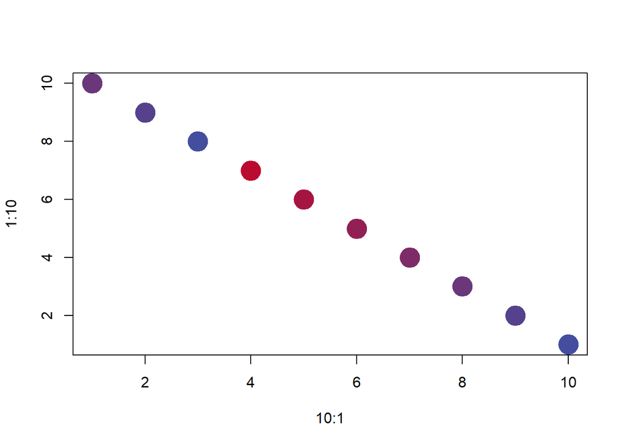

```r
# Creating a Colour Ramp
  #434E9F Blue
  #BA0A30 Pink
Colours7 <- colorRampPalette(c("#434E9F", "#BA0A30"))
plot(x=10:1, y=1:10, pch=19, cex=3, col=Colours7(7))
```

```r
# Opening Attribute CSV
NodeAttribute<- read.csv("MKN_Node_Attributes.csv",header = TRUE)
names(NodeAttribute)
colnames(NodeAttribute)[1] = "Attraction"

## Changing to Character Class
ClassColour <- as.character(NodeAttribute$Class.Colour)
Class <- as.character(NodeAttribute$Class)
RideType <- as.character(NodeAttribute$Ride.Type)
RideColour <- as.character(NodeAttribute$Ride.Type.Colour)
BigThrills <- as.character(NodeAttribute$BigThrills)
BigThrillsColour <- as.character(NodeAttribute$BigThrillColour)
ParadeNode <- as.character(NodeAttribute$ParadeNode)
ParadeLab <- as.character(NodeAttribute$ParadeLab)
NodeSLabel <- as.character(NodeAttribute$NodeSLabel)
PPColour_NP <- as.character(NodeAttribute$PPColour_NP)
PPColour_P <- as.character(NodeAttribute$PPColour_P)
BTParade <- as.character(NodeAttribute$BT_Parade)
BTNoParade <- as.character(NodeAttribute$BT_NoParade)
Land <- as.character(NodeAttribute$Land)
LandColour <- as.character(NodeAttribute$LandColour)

# Adding Attribute Data to Graph
V(NoParade)$Class <- Class
V(NoParade)$ClassColour<- ClassColour
V(NoParade)$RideType<- RideType
V(NoParade)$RideColour<- RideColour
V(NoParade)$BigThrills <- BigThrills
V(NoParade)$BigThrillsColour <- BigThrillsColour
V(NoParade)$PPColour_NP <- PPColour_NP
V(NoParade)$BTNoParade <- BTNoParade
V(NoParade)$Land <- Land
V(NoParade)$LandColour <- LandColour

# Checking Edges
edge_attr(NoParade)
E(NoParade)
```

## Establishing Graph Layout

The following R Code creates the layout for displaying the graph. Each layout is randomly generated and users may wish to repeat the code until an acceptable layout is created.

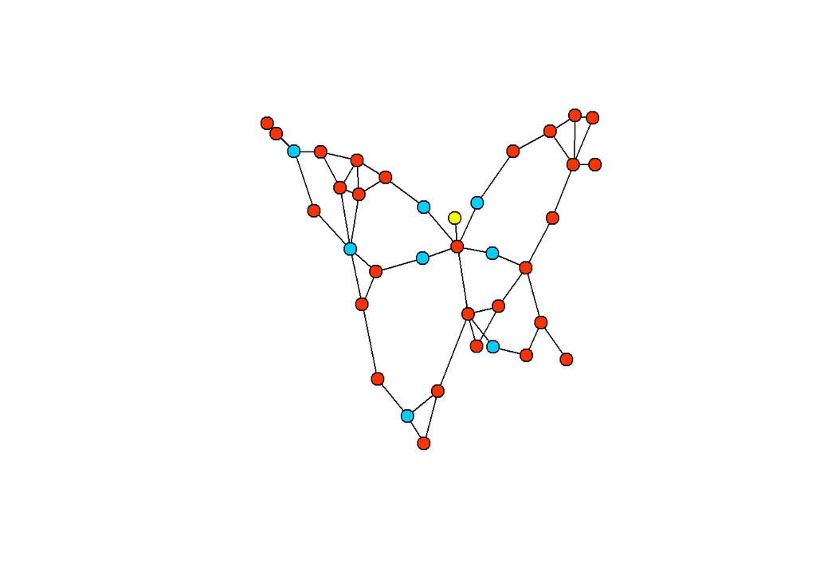

```r
# Graph Layout
l <- layout_with_fr(NoParade)

## Checking Layout
plot(NoParade,
     edge.arrow.size=0,
     edge.color="black",
     layout=l,
     vertex.label=NA,
     vertex.color=V(NoParade)$ClassColour,
     vertex.size=8)
```

### Output One: Magic Kingdom Themed Lands

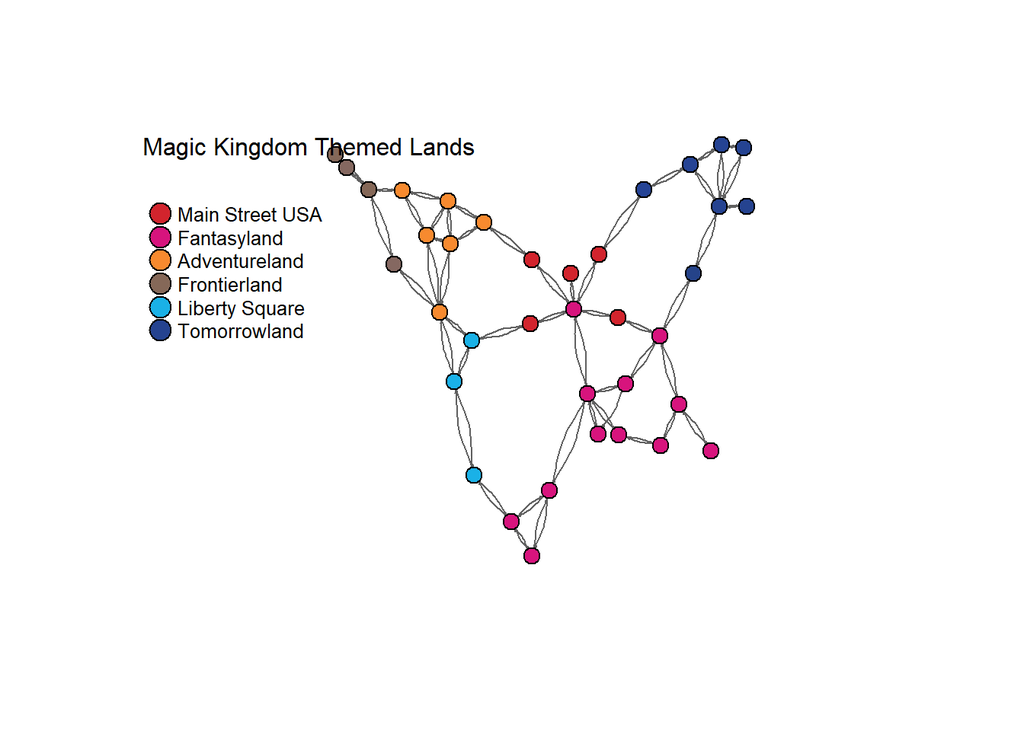

```r
# Establishing Elements
LandNames <- c("Main Street USA","Fantasyland","Adventureland","Frontierland","Liberty Square","Tomorrowland")
LndColour <- c("#D2242D","#D7147D","#F78A2F","#856858","#1AB1E6","#254390")

# Plotting
plot(NoParade,
     edge.arrow.size=.1,
     vertex.color=V(NoParade)$LandColour,
     vertex.size=8,
     vertex.label=NA,
     vertex.frame.color="black",
     edge.curved=.2,
     edge.color="#616161",
     layout=l,
     frame=FALSE)
legend(x=-1.935702, y=0.7817387, LandNames, pch=21,
       col="black", pt.bg=LndColour, pt.cex=2, cex=0.8, bty="n", ncol=1)
text(x=-2.008949,y=0.9881603,pos=4,labels="Magic Kingdom Themed Lands",cex=NULL)
```

### Output Two: Node Class

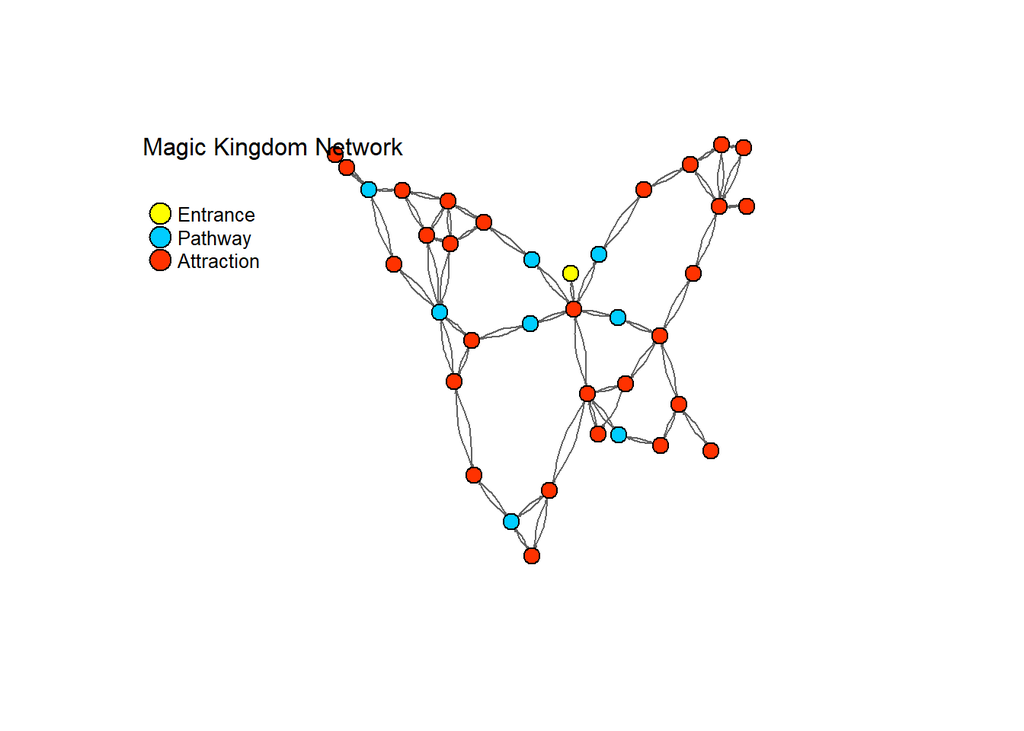

```r
# Plotting
plot(NoParade,
     edge.arrow.size=.1, #You can make this 0 to get rid of arrows.
     vertex.color=V(NoParade)$ClassColour,
     vertex.size=8,
     vertex.label=NA,
     vertex.frame.color="black",
     edge.curved=.2,
     edge.color="#616161",
     layout=l,
     frame=FALSE)
text(x=-2.008949,y=0.9881603,pos=4,labels="Magic Kingdom Network",cex=NULL)
legend(x=-1.935702, y=0.7817387, c("Entrance","Pathway","Attraction"), pch=21,
       col="black", pt.bg=c("#FFFE00","#00CDFF","#FF3200"), pt.cex=2, cex=0.8, bty="n", ncol=1)
```

### Output Three: Big Thrill Attractions

```r
# Making Legend
Legend <- data.frame(NodeAttribute$BigThrills,NodeAttribute$BigThrillColour)
Legend <- na.omit(Legend)
names(Legend)
```

```
## [1] "NodeAttribute.BigThrills"      "NodeAttribute.BigThrillColour"
```

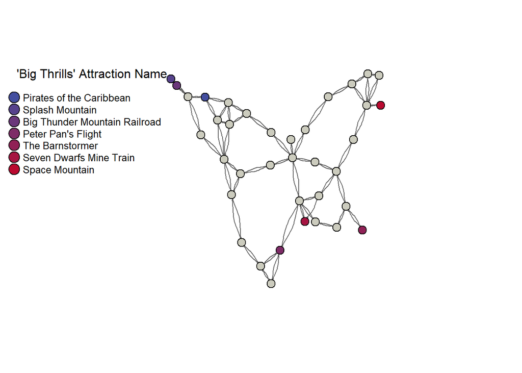

```r
colnames(Legend)[1] = "BigThrill"
colnames(Legend)[2]="Colour"
colnames(Legend)[2]="Colour"
Legend$Colour <- as.character(Legend$Colour)

# Plotting
plot(NoParade,
     edge.arrow.size=.1,
     vertex.color=V(NoParade)$BigThrillsColour,
     vertex.size=8,
     vertex.label= NA,
     vertex.label.color="black",
     vertex.label.cex=0.8,
     vertex.label.dist=1,
     vertex.frame.color="black",
     vertex.label.family="Arial",
     edge.curved=.2,
     edge.color="#616161",
     layout=l,
     frame=FALSE)
text(x=-2.539197,y=0.9976618,pos=4,labels="'Big Thrills' Attraction Name",cex=NULL)
legend(x=-2.580599, y=0.8906897, Legend$BigThrill, pch=21,
       col="black", pt.bg=Legend$Colour,
       pt.cex=2, cex=.8, bty="n", ncol=1)
```

## Creating the Parade Graph

```r
# Parade Graph
Parade<- as.matrix(read.csv("MKN_Time_Parade.csv",header = TRUE))
Attraction <- Parade[,1]
Parade <- Parade[, -1]
colnames(Parade) <- rownames(Parade) <- Attraction
Parade[is.na(Parade)] <- 0
Parade<- graph.adjacency(Parade, weighted = TRUE)
```

### Editing Edge and Node Attributes of Parade Graph

```r
# Parade Route Edge Attributes
edge_attr(Parade)


# Opening Edge Attributes CSV
EdgeAttribute<- read.csv("MKN_Edge_Attributes.csv",header = TRUE)
names(EdgeAttribute)

## Changing Parade Route Edge Attributes
EdgeColour <- as.character(EdgeAttribute$E.Colour)
E(Parade)$EColour <- EdgeColour

# Checking the Edge IDs
AO<- get.edge.ids(Parade,c("Astro Orbiter","PeopleMover"))

# Changing Parade Route Node Attributes
V(Parade)$ParadeNode <- ParadeNode
V(Parade)$ParadeLab <- ParadeLab
V(Parade)$NodeSLabel <- NodeSLabel
V(Parade)$PPColour_P <- PPColour_P
V(Parade)$BTParade <- BTParade
```

### Output Four: Parade Route

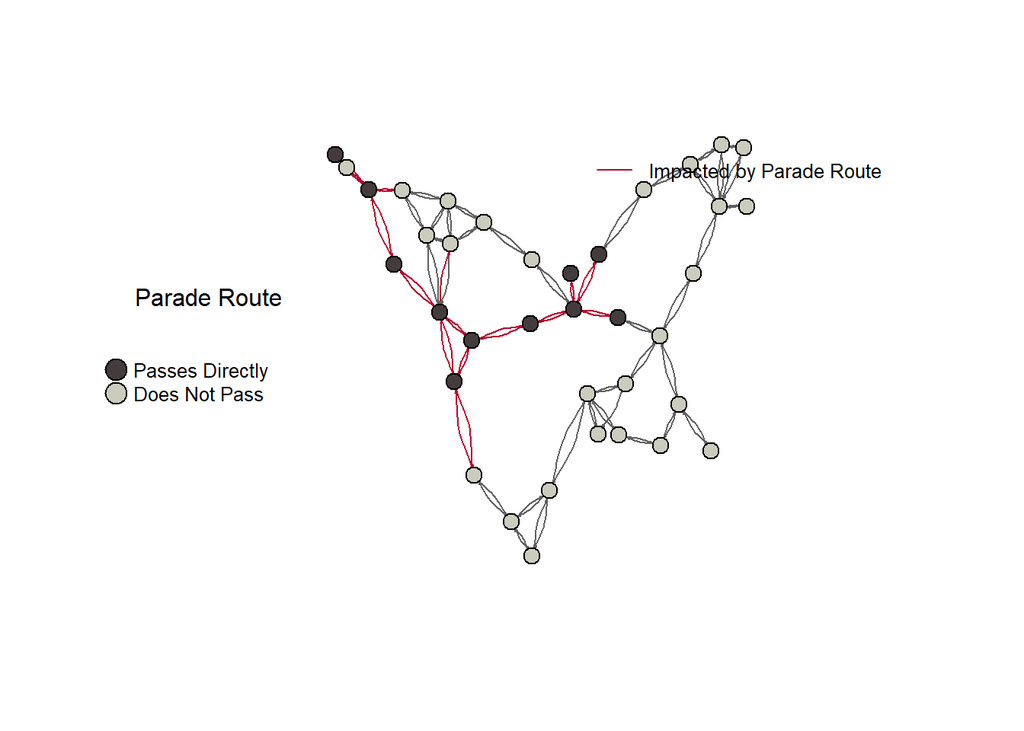

```r
# Plotting the Parade Park Route
plot(Parade,
     edge.arrow.size=.1,
     vertex.color=V(Parade)$ParadeNode,
     vertex.size=8,
     vertex.label= NA,
     vertex.label.color="Black",
     vertex.label.cex=0.8,
     vertex.label.dist=1,
     vertex.frame.color="black",
     vertex.label.family="Arial",
     edge.curved=.2,
     edge.color=E(Parade)$EColour,
     layout=l,
     frame=FALSE)
legend(x=-2.151107, y=0.0221884, c("Passes Directly","Does Not Pass"), pch=21,
       col="black", pt.bg=c("#443C3C","#CCCCBE"), pt.cex=2, cex=.8, bty="n", ncol=1)
legend(x=0.184514, y=0.991471, c("Impacted by Parade Route"), lty=1,
       col="#BA0A30", pt.cex=2, cex=.8, bty="n", ncol=1)
text(x=-2.046004,y=0.2557505,pos=4,labels="Parade Route",cex=NULL)
```

# Calculating Shortest Pathways

This section provides the R code used to analyse the graphs for Magic Kingdom, Walt Disney World. Code has been replicated or adapted from Network Visualizations with R (Ognyanova 2019).

## Shortest Pathways from All Nodes

```r
# SPA for All Nodes
## Parade
Parade_ShortestPathTime <- (s.paths <- shortest.paths(Parade, algorithm = "dijkstra"))
write.csv(Parade_ShortestPathTime,file="Parade_ShortPathTime_V2.csv")

## Non-Parade
NoParade_ShortestPathTime <- (s.paths <- shortest.paths(NoParade, algorithm = "dijkstra"))
write.csv(NoParade_ShortestPathTime,file="NoParade_ShortPathTime_V2.csv")
```

## Shortest Pathways to Big Thrill Attractions from Cinderella’s Castle

```r
# Calculating Shortest Paths from CC to Big Thrill Rides
BTRides <- c("Pirates of the Caribbean",
             "Splash Mountain",
             "Big Thunder Mountain Railroad",
             "Peter Pan's Flight",
             "The Barnstormer",
             "Seven Dwarfs Mine Train",
             "Space Mountain")
shortest_paths(Parade,"Cinderella's Castle",BTRides)
shortest_paths(NoParade,"Cinderella's Castle",BTRides)
```

### Validating Against CSV Output

```r
# Checking the Shortest Path Times
A <- E(Parade)$weight[get.edge.ids(Parade,c("Cinderella's Castle","ALB"))]
B <- E(Parade)$weight[get.edge.ids(Parade,c("ALB","Swiss Family Treehouse"))]
C <- E(Parade)$weight[get.edge.ids(Parade,c("Swiss Family Treehouse","Jungle Cruise"))]
D <- E(Parade)$weight[get.edge.ids(Parade,c("Jungle Cruise","Pirates of the Caribbean"))]
E <- E(Parade)$weight[get.edge.ids(Parade,c("Pirates of the Caribbean","FLB1"))]
G <- E(Parade)$weight[get.edge.ids(Parade,c("FLB1","Splash Mountain"))]

# Summing Objects to Confirm 19 Minute Walk Time
Test1 <- c(A,B,C,D,E,G)
sum(Test1) #19
```

### Output Five: Comparison of Nodes Along Routes: Peter Pan’s Flight

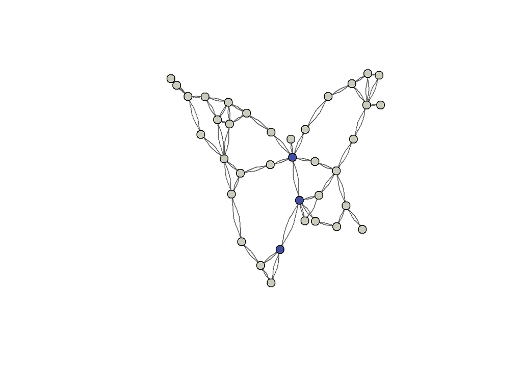

```r
#Non-Parade Route to Peter Pan's Flight
plot(NoParade,
     edge.arrow.size=.1,
     vertex.color=V(NoParade)$PPColour_NP,
     vertex.size=8,
     vertex.label= NA,
     vertex.label.color="black",
     vertex.label.cex=0.8,
     vertex.label.dist=1,
     vertex.frame.color="black",
     vertex.label.family="Arial",
     edge.curved=.2,
     edge.color="#616161",
     layout=l,
     frame=FALSE)
```

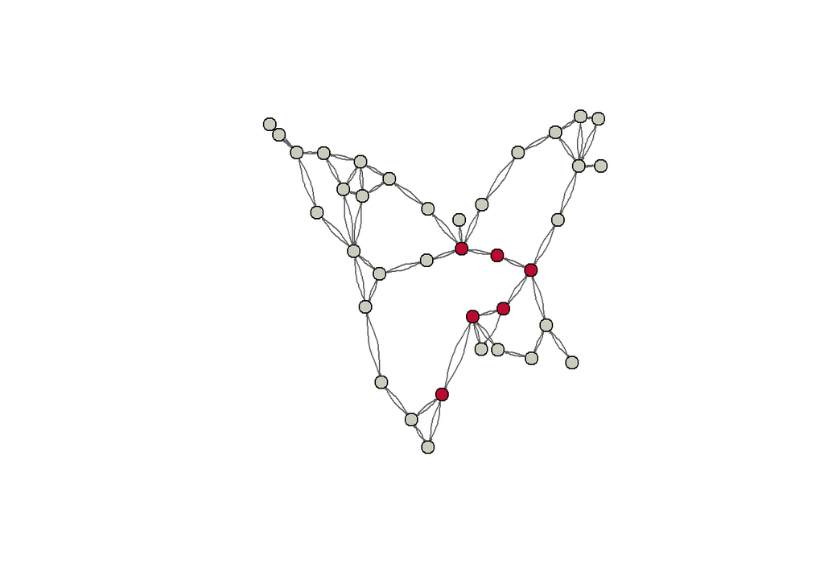

```r
# Parade Route to Peter Pan's Flight
plot(Parade,
     edge.arrow.size=.1,
     vertex.color=V(Parade)$PPColour_P,
     vertex.size=8,
     vertex.label= NA,
     vertex.label.color="black",
     vertex.label.cex=0.8,
     vertex.label.dist=1,
     vertex.frame.color="black",
     vertex.label.family="Arial",
     edge.curved=.2,
     edge.color="#616161",
     layout=l,
     frame=FALSE)
```

### Output Six: Comparison of Nodes Along Routes: Big Thunder Mountain Railroad

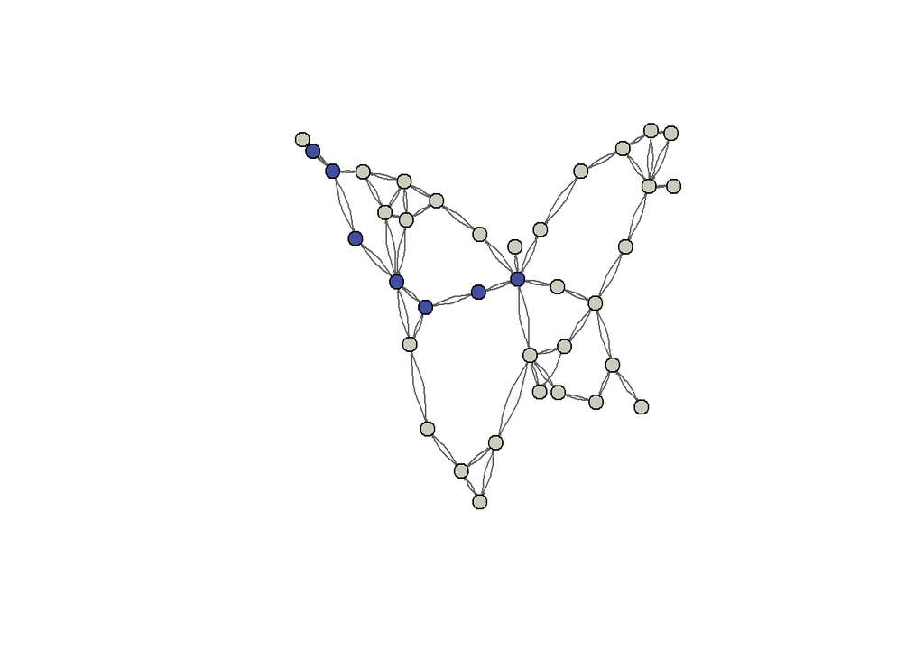

```r
# Non-Parade Route to Big Thunder Mountain
plot(NoParade,
     edge.arrow.size=.1,
     vertex.color=V(NoParade)$BTNoParade,
     vertex.size=8,
     vertex.label= NA,
     vertex.label.color="black",
     vertex.label.cex=0.8,
     vertex.label.dist=1,
     vertex.frame.color="black",
     vertex.label.family="Arial",
     edge.curved=.2,
     edge.color="#616161",
     layout=l,
     frame=FALSE)
```

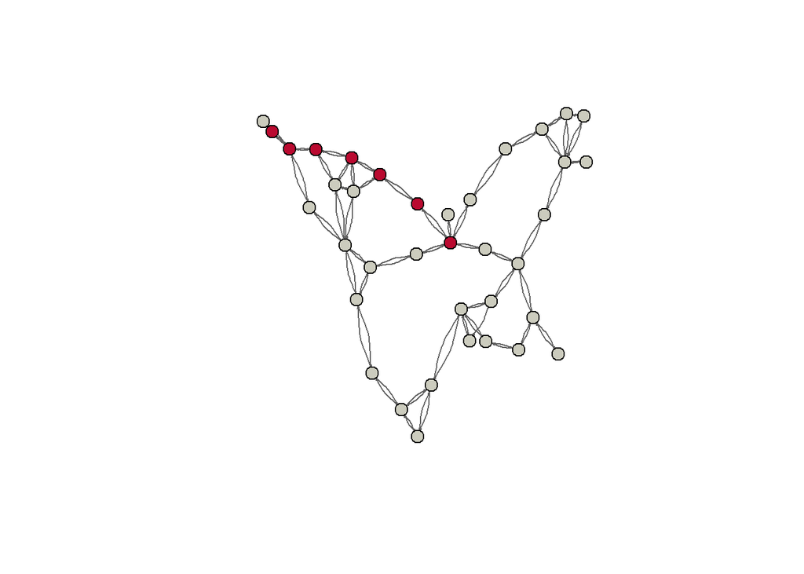

```r
# Parade Route to Big Thunder Mountain
plot(Parade,
     edge.arrow.size=.1,
     vertex.color=V(Parade)$BTParade,
     vertex.size=8,
     vertex.label= NA,
     vertex.label.color="black",
     vertex.label.cex=0.8,
     vertex.label.dist=1,
     vertex.frame.color="black",
     vertex.label.family="Arial",
     edge.curved=.2,
     edge.color="#616161",
     layout=l,
     frame=FALSE)
```

# Chi Squared Analysis

This section provides the R code used to undertake Chi Squared Analysis based Logan (2011).

```r
# Chi Squared of Average Walk Times from All Nodes to Each  Node
AllChi<- read.csv("All_Chi.csv",header = TRUE)
All_Chi <- chisq.test(AllChi)
All_Chi
```

```
##
##  Pearson's Chi-squared test
##
## data:  AllChi
## X-squared = 6.5364, df = 36, p-value = 1
```

```r
# Chi Squared of Walk Time from Cinderella's Castle to Big Thrill Attractions
BTAChi <- read.csv("Chi_Rides.csv",header = TRUE)
BTA_Chi <- chisq.test(BTAChi)
BTA_Chi
```

```
##
##  Pearson's Chi-squared test
##
## data:  BTAChi
## X-squared = 2.133, df = 6, p-value = 0.9071
```

# References

- Logan, M., 2011. *Biostatistical design and analysis using R: a practical guide*. John Wiley & Sons.
- Ognyanova, K. 2019. *Network visualization with R* [online]. Available from: https://www.researchgate.net/profile/Katherine_Ognyanova/publication/335679918_Network_visualization_with_R/links/5d73b6e3299bf1cb808fd9b2/Network-visualization-with-R.pdf [Accessed 11 March 2020]